# p8105_linear_models

Jana Lee

11/7/2019

## Lecture: Linear Regression

lm = linear model, continuous outcome variable glm = generalized linear models, binary outcome

arguments include: - formula: y~x1 + x2 - data

Outputs are kind of a mess, but we can use the broom package to clean it up.

### Fit a model:

```r
library(p8105.datasets)
set.seed(1)

data("nyc_airbnb")

# Qustion: Is it possible to predict price based on a couple of preditors?
# Initial data cleaning:
nyc_airbnb =
  nyc_airbnb %>%
  mutate(stars = review_scores_location / 2) %>%
  rename(
    boro = neighbourhood_group,
    neighborhood = neighbourhood) %>%
  filter(boro != "Staten Island") %>%
  select(price, stars, boro, neighborhood, room_type)
```

Fit the first linear model: When you fit 4 categorical variables, it is going to organize this by alphabetical order. Bronx becomes our reference category. Stars = if stars go up by 1-unit, airbnb increase 31.99 dollars Boro_Brooklyn = if brooklyn goes up about 1-unit, airbnb increases 40.50 dollars

```r
fit = lm(price ~ stars + boro, data = nyc_airbnb)

# this is kind of helpful: summary
summary(fit)
```

```
##
## Call:
## lm(formula = price ~ stars + boro, data = nyc_airbnb)
##
## Residuals:
##    Min     1Q Median     3Q    Max
## -169.8  -64.0  -29.0   20.2 9870.0
##
## Coefficients:
##               Estimate Std. Error t value Pr(>|t|)
## (Intercept)    -70.414     14.021  -5.022 5.14e-07 ***
## stars           31.990      2.527  12.657  < 2e-16 ***
## boroBrooklyn    40.500      8.559   4.732 2.23e-06 ***
## boroManhattan   90.254      8.567  10.534  < 2e-16 ***
## boroQueens      13.206      9.065   1.457    0.145
## ---
## Signif. codes:  0 '***' 0.001 '**' 0.01 '*' 0.05 '.' 0.1 ' ' 1
##
## Residual standard error: 181.5 on 30525 degrees of freedom
##   (9962 observations deleted due to missingness)
## Multiple R-squared:  0.03423,    Adjusted R-squared:  0.03411
## F-statistic: 270.5 on 4 and 30525 DF,  p-value: < 2.2e-16
```

```r
#Another way of extracting results
summary(fit)$coef
```

```
##                Estimate Std. Error   t value     Pr(>|t|)
## (Intercept)   -70.41446  14.020697 -5.022180 5.137589e-07
## stars          31.98989   2.527500 12.656733 1.269392e-36
## boroBrooklyn   40.50030   8.558724  4.732049 2.232595e-06
## boroManhattan  90.25393   8.567490 10.534465 6.638618e-26
## boroQueens     13.20617   9.064879  1.456850 1.451682e-01
```

```r
# extract coefficients out
coef(fit)
```

```
##   (Intercept)         stars  boroBrooklyn boroManhattan    boroQueens
##     -70.41446      31.98989      40.50030      90.25393      13.20617
```

```r
fitted.values(fit)
```

[output not shown]

[output cut: 10123 more lines]

[output not shown]

```r
#tidying results, changing the string variable to make it easier to read, and presenting this in a table
fit %>%
  broom::tidy() %>%
  mutate(term = str_replace(term, "boro", "Boro:")) %>%
  knitr::kable(digits = 3)
```

| term | estimate | std.error | statistic | p.value |
| --- | --- | --- | --- | --- |
| (Intercept) | -70.414 | 14.021 | -5.022 | 0.000 |
| stars | 31.990 | 2.527 | 12.657 | 0.000 |
| Boro:Brooklyn | 40.500 | 8.559 | 4.732 | 0.000 |
| Boro:Manhattan | 90.254 | 8.567 | 10.534 | 0.000 |
| Boro:Queens | 13.206 | 9.065 | 1.457 | 0.145 |

Looking at factors…

```r
# put categorical factors in order based on what is most common, which borough is more frequent?
nyc_airbnb =
  nyc_airbnb %>%
  mutate(
    boro = fct_infreq(boro),
    room_type = fct_infreq(room_type)
  )
```

Refitting the last model, now that factors have been reordered:

```r
fit = lm(price ~ stars + boro, data = nyc_airbnb)

fit %>%
  broom::tidy()
```

```
## # A tibble: 5 x 5
##   term         estimate std.error statistic   p.value
##   <chr>           <dbl>     <dbl>     <dbl>     <dbl>
## 1 (Intercept)      19.8     12.2       1.63 1.04e-  1
## 2 stars            32.0      2.53     12.7  1.27e- 36
## 3 boroBrooklyn    -49.8      2.23    -22.3  6.32e-109
## 4 boroQueens      -77.0      3.73    -20.7  2.58e- 94
## 5 boroBronx       -90.3      8.57    -10.5  6.64e- 26
```

Extract this information: r-squared, p-value, df, etc.

```r
fit %>%
  broom::glance()
```

```
## # A tibble: 1 x 11
##   r.squared adj.r.squared sigma statistic   p.value    df  logLik    AIC
##       <dbl>         <dbl> <dbl>     <dbl>     <dbl> <int>   <dbl>  <dbl>
## 1    0.0342        0.0341  182.      271. 6.73e-229     5 -2.02e5 4.04e5
## # … with 3 more variables: BIC <dbl>, deviance <dbl>, df.residual <int>
```

### Diagnostic information:

-The `modelr` package can be used to add residuals and fitted values to a dataframe. This will add in the residuals.

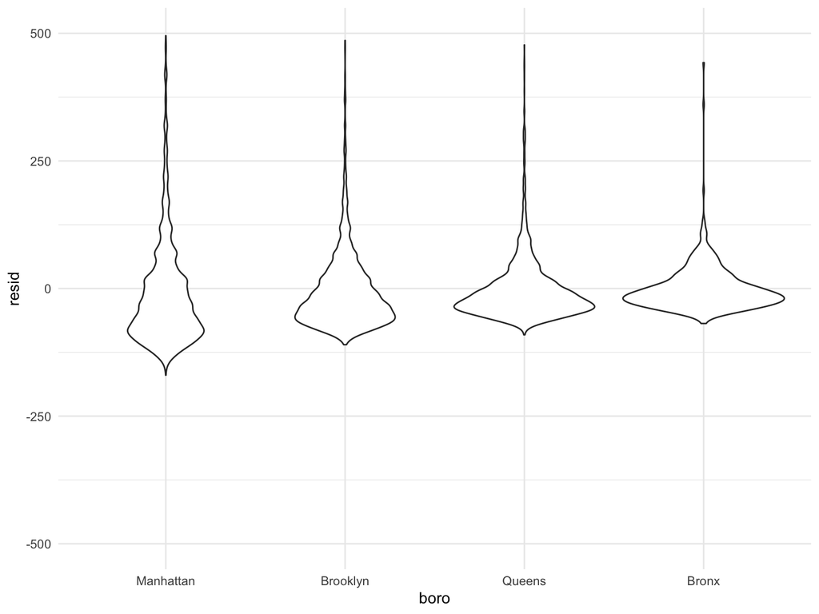

```r
modelr::add_residuals(nyc_airbnb, fit) %>%
  ggplot(aes(x = boro, y = resid)) +
  geom_violin() +
  ylim(-500, 500)
```

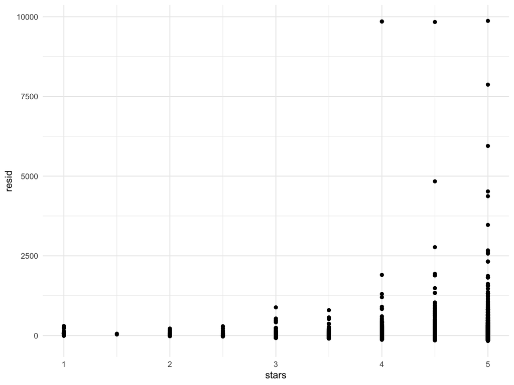

```r
nyc_airbnb %>%
  modelr::add_residuals(fit) %>%
  ggplot(aes(x = stars, y = resid)) + geom_point()
```

What is the predicted values this model gives?

```r
modelr::add_predictions(nyc_airbnb, fit)
```

```
## # A tibble: 40,492 x 6
##    price stars boro  neighborhood room_type        pred
##    <dbl> <dbl> <fct> <chr>        <fct>           <dbl>
##  1    99   5   Bronx City Island  Private room     89.5
##  2   200  NA   Bronx City Island  Private room     NA
##  3   300  NA   Bronx City Island  Entire home/apt  NA
##  4   125   5   Bronx City Island  Entire home/apt  89.5
##  5    69   5   Bronx City Island  Private room     89.5
##  6   125   5   Bronx City Island  Entire home/apt  89.5
##  7    85   5   Bronx City Island  Entire home/apt  89.5
##  8    39   4.5 Bronx Allerton     Private room     73.5
##  9    95   5   Bronx Allerton     Entire home/apt  89.5
## 10   125   4.5 Bronx Allerton     Entire home/apt  73.5
## # … with 40,482 more rows
```

### Hypothesis Testing (skipping this)

```r
fit_null = lm(price ~ stars + boro, data = nyc_airbnb)
fit_alt = lm(price ~ stars + boro + room_type, data = nyc_airbnb)

anova(fit_null, fit_alt) %>%
  broom::tidy()
```

```
## # A tibble: 2 x 6
##   res.df         rss    df     sumsq statistic p.value
##    <dbl>       <dbl> <dbl>     <dbl>     <dbl>   <dbl>
## 1  30525 1005601724.    NA       NA        NA       NA
## 2  30523  921447496.     2 84154228.     1394.       0
```

This works for nested models only. Comparing non-nested models requires other methods –> aka cross validation.

### Nesting Data

We’ll now turn our attention to fitting models to datasets nested within variables – meaning, essentially, that we’ll use nest to create a list column containing datasets and fit separate models to each. This is very different from fitting nested models, even though the terminology is similar.

In the airbnb data, we might think that star ratings and room type affects price differently in each borough. One way to allow this kind of effect modification is through interaction terms:

```r
fit_interaction = lm(price ~ stars * boro, data = nyc_airbnb)

fit_interaction %>%
  broom::tidy()
```

```
## # A tibble: 8 x 5
##   term               estimate std.error statistic  p.value
##   <chr>                 <dbl>     <dbl>     <dbl>    <dbl>
## 1 (Intercept)           -34.3     19.8     -1.73  8.34e- 2
## 2 stars                  43.3      4.13    10.5   1.05e-25
## 3 boroBrooklyn           23.0     25.9      0.887 3.75e- 1
## 4 boroQueens             52.4     41.8      1.25  2.10e- 1
## 5 boroBronx              84.2     80.2      1.05  2.93e- 1
## 6 stars:boroBrooklyn    -15.3      5.46    -2.81  5.02e- 3
## 7 stars:boroQueens      -27.5      8.90    -3.09  2.00e- 3
## 8 stars:boroBronx       -38.4     17.9     -2.15  3.16e- 2
```

```r
# This is asking: what the effect of stars for each borough on the price of airbnb? If you're looking on airbnb rentals in manhattan, this is gonna matter how much you pay. But queens and bronx, it won't really matter.

fit_interaction = lm(price ~ stars * boro + room_type*boro, data = nyc_airbnb)
# We can look at the interaction of room_type as well! This model is very flexible. Different model for the effect of stars and the effect of borough / room type.
```

```r
nyc_airbnb %>%
  filter(boro == "Brooklyn") %>%
  lm(price ~ stars + room_type, data = .) %>%
  broom::tidy()
```

```
## # A tibble: 4 x 5
##   term                  estimate std.error statistic   p.value
##   <chr>                    <dbl>     <dbl>     <dbl>     <dbl>
## 1 (Intercept)               69.6     14.0       4.96 7.27e-  7
## 2 stars                     21.0      2.98      7.05 1.90e- 12
## 3 room_typePrivate room    -92.2      2.72    -34.0  6.40e-242
## 4 room_typeShared room    -106.       9.43    -11.2  4.15e- 29
```

Trying mapping instead. Alternatively, we can nest within boroughs and fit borough-specific models associating price with rating and room type:

```r
nyc_airbnb %>%
  nest(data = -boro) %>%
  mutate(
    models = map(.x = data, ~lm(price ~ stars + room_type, data = .x)),
    results = map(models, broom::tidy)
  ) %>%
  select(boro, results) %>%
  unnest(results)
```

```
## # A tibble: 16 x 6
##    boro      term                  estimate std.error statistic   p.value
##    <fct>     <chr>                    <dbl>     <dbl>     <dbl>     <dbl>
##  1 Bronx     (Intercept)              90.1      15.2       5.94 5.73e-  9
##  2 Bronx     stars                     4.45      3.35      1.33 1.85e-  1
##  3 Bronx     room_typePrivate room   -52.9       3.57    -14.8  6.21e- 41
##  4 Bronx     room_typeShared room    -70.5       8.36     -8.44 4.16e- 16
##  5 Queens    (Intercept)              91.6      25.8       3.54 4.00e-  4
##  6 Queens    stars                     9.65      5.45      1.77 7.65e-  2
##  7 Queens    room_typePrivate room   -69.3       4.92    -14.1  1.48e- 43
##  8 Queens    room_typeShared room    -95.0      11.3      -8.43 5.52e- 17
##  9 Brooklyn  (Intercept)              69.6      14.0       4.96 7.27e-  7
## 10 Brooklyn  stars                    21.0       2.98      7.05 1.90e- 12
## 11 Brooklyn  room_typePrivate room   -92.2       2.72    -34.0  6.40e-242
## 12 Brooklyn  room_typeShared room   -106.        9.43    -11.2  4.15e- 29
## 13 Manhattan (Intercept)              95.7      22.2       4.31 1.62e-  5
## 14 Manhattan stars                    27.1       4.59      5.91 3.45e-  9
## 15 Manhattan room_typePrivate room  -124.        3.46    -35.8  9.40e-270
## 16 Manhattan room_typeShared room   -154.       10.1     -15.3  2.47e- 52
```

## Let’s nest neighborhoods

```r
manhattan_airbnb =
  nyc_airbnb %>%
  filter(boro == "Manhattan")

manhattan_nest_lm_res =
  manhattan_airbnb %>%
  nest(data = -neighborhood) %>%
  mutate(models = map(data, ~lm(price ~ stars + room_type, data = .x)),
         models = map(models, broom::tidy)) %>%
  select(-data) %>%
  unnest(models)
```

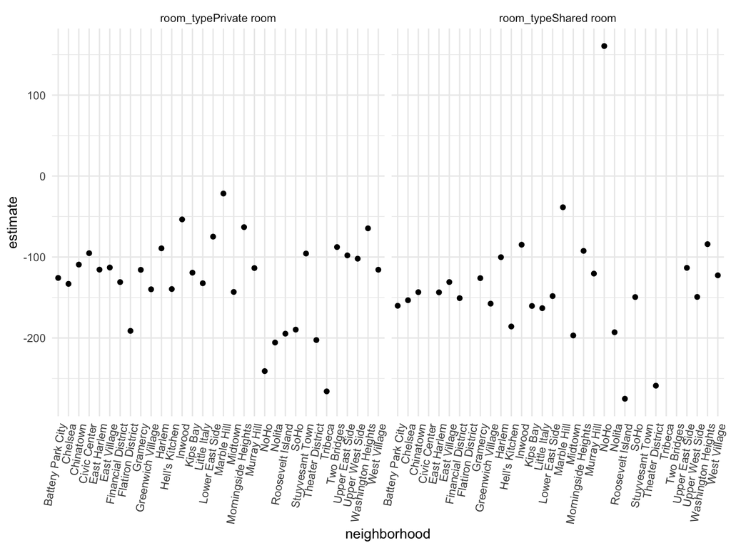

```r
manhattan_nest_lm_res %>%
  filter(str_detect(term, "room_type")) %>%
  ggplot(aes(x = neighborhood, y = estimate)) +
  geom_point() +
  facet_wrap(~term) +
  theme(axis.text.x = element_text(angle = 80, hjust = 1))
```

Deep dive into NoHo room, where shared room is more expensive than private room:

```r
nyc_airbnb %>%
  filter(neighborhood == "NoHo", room_type == "Shared room")
```

```
## # A tibble: 1 x 5
##   price stars boro      neighborhood room_type
##   <dbl> <dbl> <fct>     <chr>        <fct>
## 1   219     4 Manhattan NoHo         Shared room
```

### Binary Outcomes

Using homicide dataset from Washington Post. We will use the unresolved murders in Baltimore, MD to illustrate logistic regression.

Need to specify family (binomial)

```r
baltimore_df =
  read_csv("data/homicide-data.csv") %>%
  filter(city == "Baltimore") %>%
  mutate(
    resolved = as.numeric(disposition == "Closed by arrest"),
    victim_age = as.numeric(victim_age),
    victim_race = fct_relevel(victim_race, "White")) %>%
  select(resolved, victim_age, victim_race, victim_sex)
```

Fit a logistic regression for the binary “resolved” outcome and victim demographics as predictors. Uses glm function with the family specified to account for non-Gaussian outcome distribution.

```r
fit_logistic =
  baltimore_df %>%
  glm(resolved ~ victim_age + victim_race + victim_sex, data = ., family = binomial())
```

Using logistic regression to get ORs:

```r
fit_logistic %>%
  broom::tidy() %>%
  mutate(OR = exp(estimate)) %>%
  select(term, log_OR = estimate, OR, p.value) %>%
  knitr::kable(digits = 3)
```

| term | log_OR | OR | p.value |
| --- | --- | --- | --- |
| (Intercept) | 1.190 | 3.287 | 0.000 |
| victim_age | -0.007 | 0.993 | 0.027 |
| victim_raceAsian | 0.296 | 1.345 | 0.653 |
| victim_raceBlack | -0.842 | 0.431 | 0.000 |
| victim_raceHispanic | -0.265 | 0.767 | 0.402 |
| victim_raceOther | -0.768 | 0.464 | 0.385 |
| victim_sexMale | -0.880 | 0.415 | 0.000 |

Compute fitted values to estimate the model summary

```r
baltimore_df %>%
  modelr::add_predictions(fit_logistic) %>%
  mutate(fitted_prob = boot::inv.logit(pred))
```

```
## # A tibble: 2,827 x 6
##    resolved victim_age victim_race victim_sex    pred fitted_prob
##       <dbl>      <dbl> <fct>       <chr>        <dbl>       <dbl>
##  1        0         17 Black       Male       -0.654        0.342
##  2        0         26 Black       Male       -0.720        0.327
##  3        0         21 Black       Male       -0.683        0.335
##  4        1         61 White       Male       -0.131        0.467
##  5        1         46 Black       Male       -0.864        0.296
##  6        1         27 Black       Male       -0.727        0.326
##  7        1         21 Black       Male       -0.683        0.335
##  8        1         16 Black       Male       -0.647        0.344
##  9        1         21 Black       Male       -0.683        0.335
## 10        1         44 Black       Female      0.0297       0.507
## # … with 2,817 more rows
```

In Baltimore, race disparities exist. Can map across all the cities in the datasets across all cities.

## Lecture: Cross-Validation

```r
library (tidyverse)
library(modelr)
library(mgcv)
set.seed(1)
```

mgcv::gam = go-to package for “additive models”

### Doing cross-validation by hand. Simulated example.

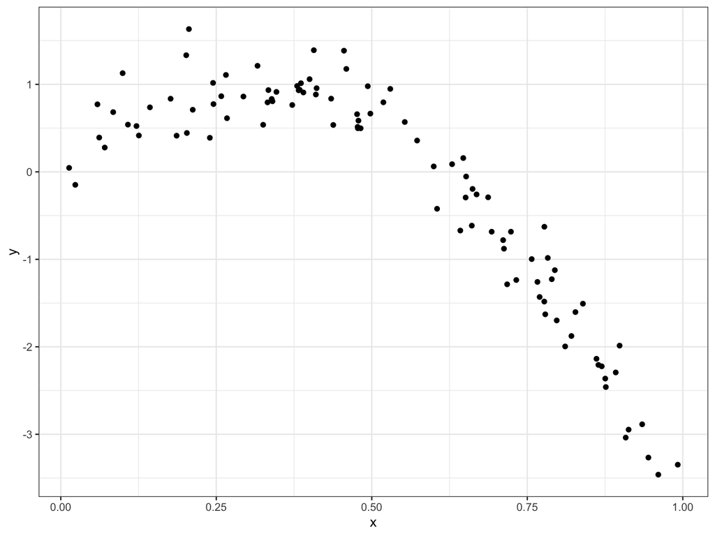

```r
nonlin_df =
  tibble(
    id = 1:100,
    x = runif(100, 0, 1),
    y = 1 - 10 * (x - .3) ^ 2 + rnorm(100, 0, .3)
  )

nonlin_df %>%
  ggplot(aes(x = x, y = y)) +
  geom_point() + theme_bw()
```

training vs. testing datasets. Goal is to use the training data (black) to build candidate models and then see how those models predict in the testing data (red)

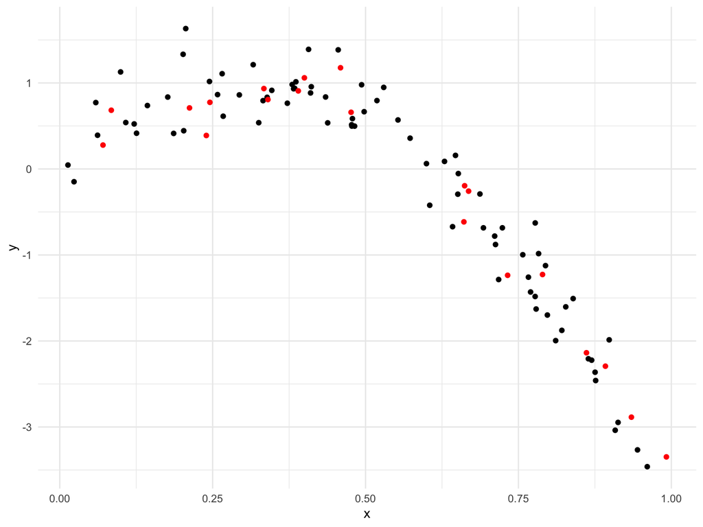

```r
train_df = sample_n(nonlin_df, 80)
test_df = anti_join(nonlin_df, train_df, by = "id")

ggplot(train_df, aes(x = x, y = y)) +
  geom_point() +
  geom_point(data = test_df, color = "red")
```

Fit 3 models of varying goodness

```r
linear_mod = lm(y ~ x, data = train_df)
smooth_mod = mgcv::gam(y ~ s(x), data = train_df)
wiggly_mod = mgcv::gam(y ~ s(x, k = 30), sp = 10e-6, data = train_df)
```

Using the 3 models and testing that with the add_prediction area. How can I compare these different models that would confirm these?

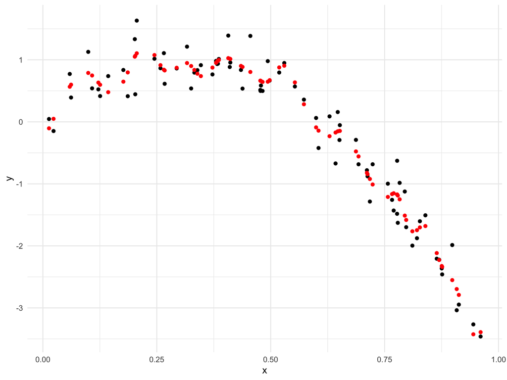

```r
train_df %>%
  add_predictions(wiggly_mod) %>%
  ggplot(aes(x = x, y = y)) +
  geom_point() +
  geom_point(aes(y = pred), color = "red")
```

Faceting these 3 models

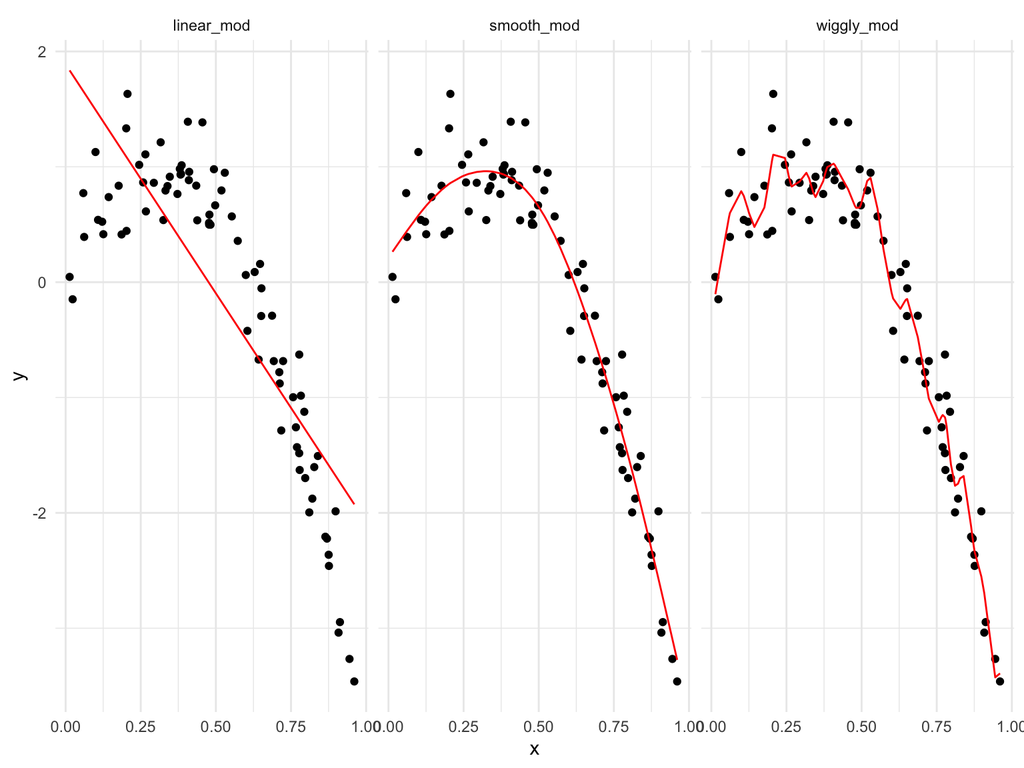

```r
train_df %>%
  gather_predictions(linear_mod, smooth_mod, wiggly_mod) %>%
  mutate(model = fct_inorder(model)) %>%
  ggplot(aes(x = x, y = y)) +
  geom_point() +
  geom_line(aes(y = pred), color = "red") +
  facet_wrap(~model)
```

Quick visual inspection shows us that the linear model is too simple, the standard gam is pretty good and the wiggy gam is too complex.

Next step: Computing root mean squared errors (RMSEs) for each model. Always pick the model that will do better on the testing dataset

```r
rmse(linear_mod, test_df)
```

```
## [1] 0.7052956
```

```r
rmse(smooth_mod, test_df)
```

```
## [1] 0.2221774
```

```r
rmse(wiggly_mod, test_df)
```

```
## [1] 0.289051
```

We see that both non-linear models work better than the linear model. But we need to understand if the model is stable, so we need t o iterate this whole process.

### Cross Validation in model r

80-20 is the default for crossv_mc

```r
cv_df =
  crossv_mc(nonlin_df, 100)
```

```r
cv_df =
  cv_df %>%
  mutate(
    train = map(train, as_tibble),
    test = map(test, as_tibble))
```

Iterate this for the following models map1 = just gives you one map2 = gives you first column and second column (models, datasets)

```r
cv_results =
  cv_df %>%
  mutate(linear_mod  = map(train, ~lm(y ~ x, data = .x)),
         smooth_mod  = map(train, ~mgcv::gam(y ~ s(x), data = .x)),
         wiggly_mod  = map(train, ~mgcv::gam(y ~ s(x, k = 30), sp = 10e-6, data = .x))) %>%
  mutate(rmse_linear = map2_dbl(linear_mod, test, ~rmse(model = .x, data = .y)),
         rmse_smooth = map2_dbl(smooth_mod, test, ~rmse(model = .x, data = .y)),
         rmse_wiggly = map2_dbl(wiggly_mod, test, ~rmse(model = .x, data = .y)))
```

Data Manipulation - RMSE is above. Going to pick the smooth model bc it has the lowest RMSE

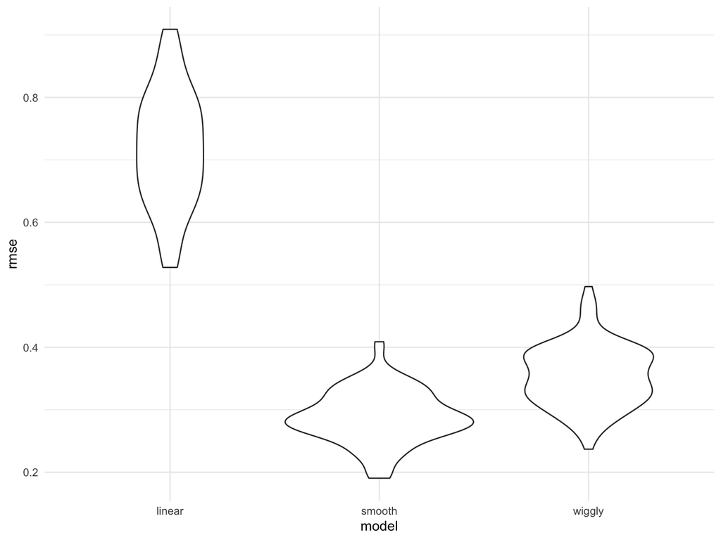

```r
cv_results %>%
  select(starts_with("rmse")) %>%
  pivot_longer(
    everything(),
    names_to = "model",
    values_to = "rmse",
    names_prefix = "rmse_") %>%
  mutate(model = fct_inorder(model)) %>%
  ggplot(aes(x = model, y = rmse)) + geom_violin()
```

Here, iteration is helpful. We get a sense of the variance in prediction error and can compare prediction error distributions across methods. The smooth is a clear winner!

### Example with Child Growth

```r
child_growth = read_csv("./data/nepalese_children.csv")
```

We think that non-linearity might be happening here.

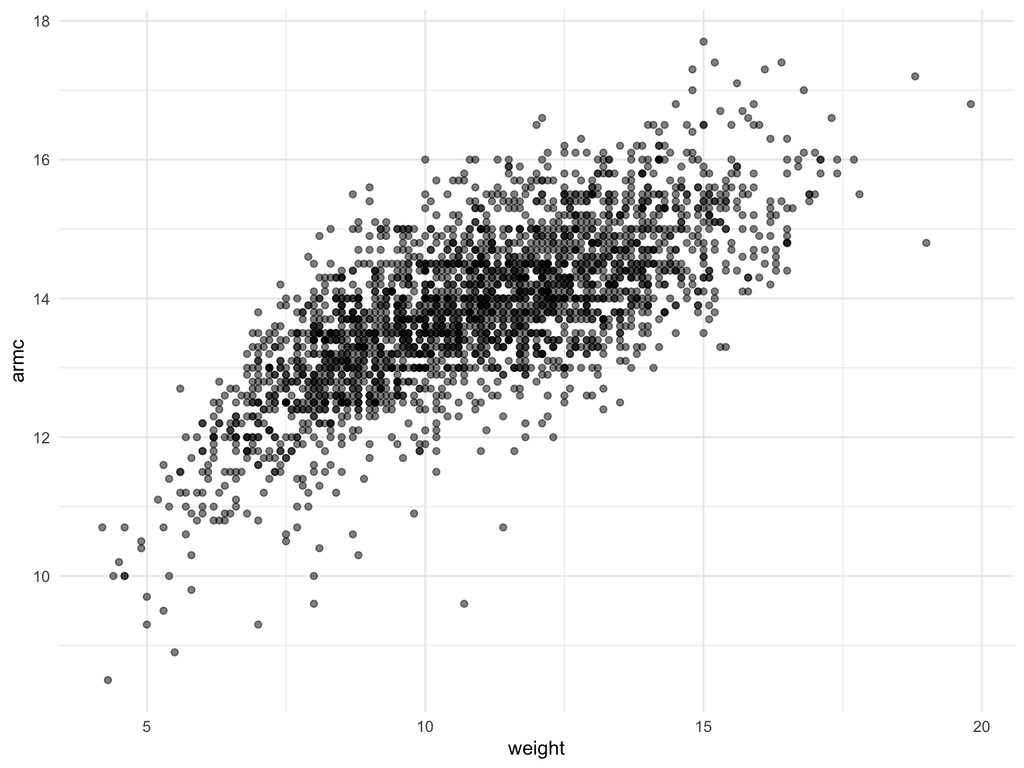

```r
child_growth %>%
  ggplot(aes(x = weight, y = armc)) +
  geom_point(alpha = .5)
```

Plot suggests some non-linearity, especially at the low end of the weight distirbution.

Add code to do change point term

```r
child_growth =
  child_growth %>%
  mutate(weight_cp = (weight > 7) * (weight - 7))
```

Checking goodness of fit

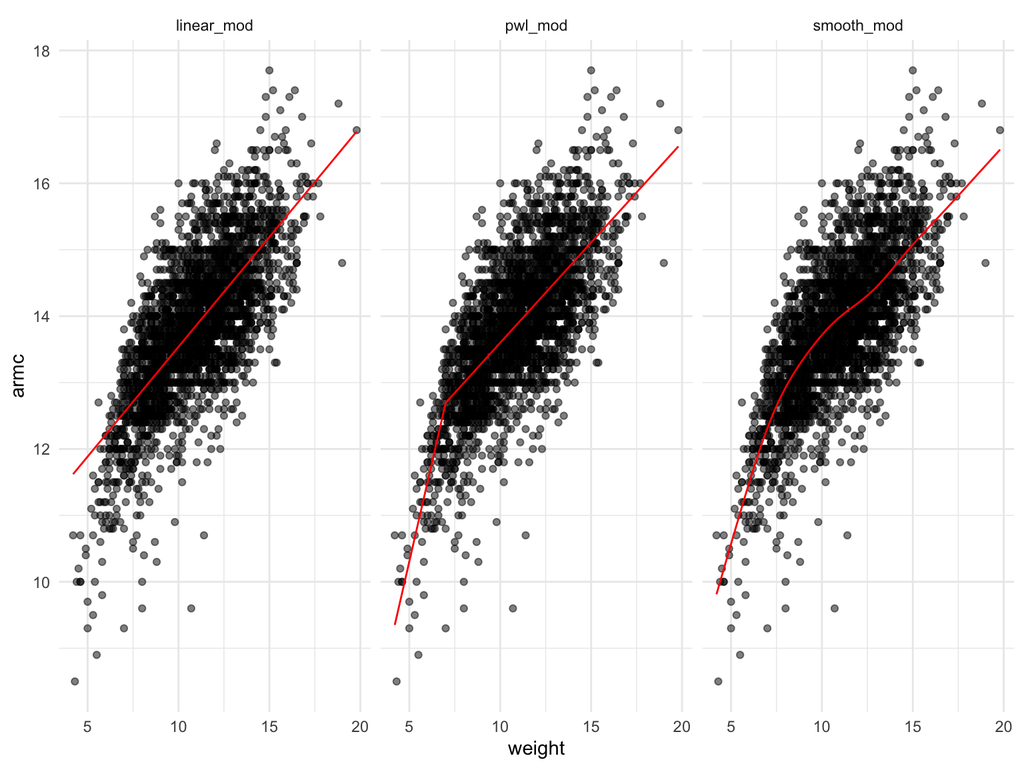

```r
linear_mod = lm(armc ~ weight, data = child_growth)
pwl_mod = lm(armc ~ weight + weight_cp, data = child_growth)
smooth_mod = gam(armc ~ s(weight), data = child_growth)

child_growth %>%
  gather_predictions(linear_mod, pwl_mod, smooth_mod) %>%
  mutate(model = fct_inorder(model)) %>%
  ggplot(aes(x = weight, y = armc)) +
  geom_point(alpha = .5) +
  geom_line(aes(y = pred), color = "red") +
  facet_grid(~model)
```

From the facet, it’s not clear which is best. But the piecewise and non-linear models are pretty similar.

Convert the resample obsjects to dataframes

```r
cv_df =
  crossv_mc(child_growth, 100) %>%
  mutate(
    train = map(train, as_tibble),
    test = map(test, as_tibble))
```

Use mutate, map, and map2 to fit models to training data and obtain RMSEs for testing data

```r
cv_df =
  cv_df %>%
  mutate(linear_mod  = map(train, ~lm(armc ~ weight, data = .x)),
         pwl_mod = map(train, ~lm(armc ~ weight + weight_cp, data = .x)),
         smooth_mod = map(train, ~gam(armc ~ s(weight), data = as_tibble(.x)))) %>%
  mutate(rmse_linear = map2_dbl(linear_mod, test, ~rmse(model = .x, data = .y)),
         rmse_pwl    = map2_dbl(pwl_mod, test, ~rmse(model = .x, data = .y)),
         rmse_smooth = map2_dbl(smooth_mod, test, ~rmse(model = .x, data = .y)))
```

Plot the prediction error distribution for each candidate model

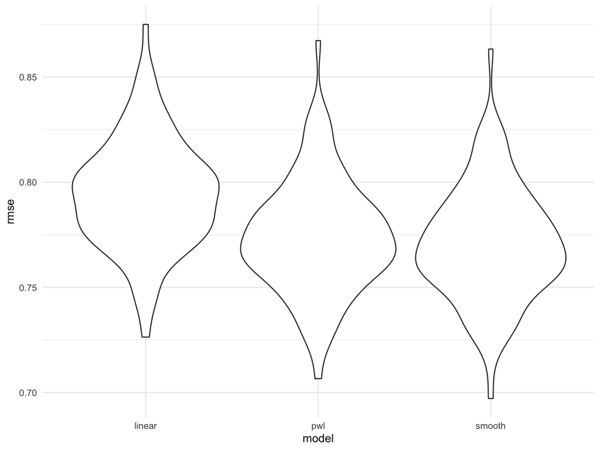

```r
cv_df %>%
  select(starts_with("rmse")) %>%
pivot_longer(
    everything(),
    names_to = "model",
    values_to = "rmse",
    names_prefix = "rmse_") %>%
  mutate(model = fct_inorder(model)) %>%
  ggplot(aes(x = model, y = rmse)) + geom_violin()
```

There’s some improvement in predictive accuracy gained by allowing non-linearity. Between the two, go with piecewise and gam fits because they are easier to interpret.